# 3.6.1 DSSD 多重性事件分析-I

### 目的：

- 根据相邻条关联和正背面关联，确认多重触发事件的入射位置、能量，并重新组织事件
- 根据位置-能量关联，对事件进行分类

### 数据：

- d1-d3探测器的幅度已归一化。
- hit结构中能量按照由大到小排序。

```
Int_t  x1hit;      //multiplicity
Int_t  x1[x1hit];  //Strip
double  x1e[x1hit]; //energy

Int_t  y1hit;
Int_t  y1[y1hit];
Int_t  y1e[y1hit];

double x1es,y1es; //total energy of x,y side.
int x1m,y1m;      //multiplicity, adjacent tracks are counted as one.
```

```python
//%jsroot on
TFile *ipf = new TFile("./data/cal_16C.root");
TTree *tree = (TTree*)ipf->Get("tree");
TCanvas *c1=new TCanvas;
```

### Hit Pattern

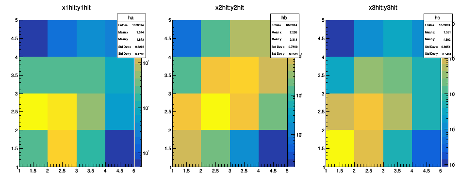

```python
c1->Clear();
c1->SetWindowSize(1200,300);
c1->Divide(3,1);
c1->cd(1);
gPad->SetLogz();
tree->Draw("x1hit:y1hit>>ha(4,1,5,4,1,5)","","colz");
c1->cd(2);
gPad->SetLogz();
tree->Draw("x2hit:y2hit>>hb(4,1,5,4,1,5)","","colz");
c1->cd(3);
gPad->SetLogz();
tree->Draw("x3hit:y3hit>>hc(4,1,5,4,1,5)","","colz");
c1->Draw();
```

## 1. x-y关联

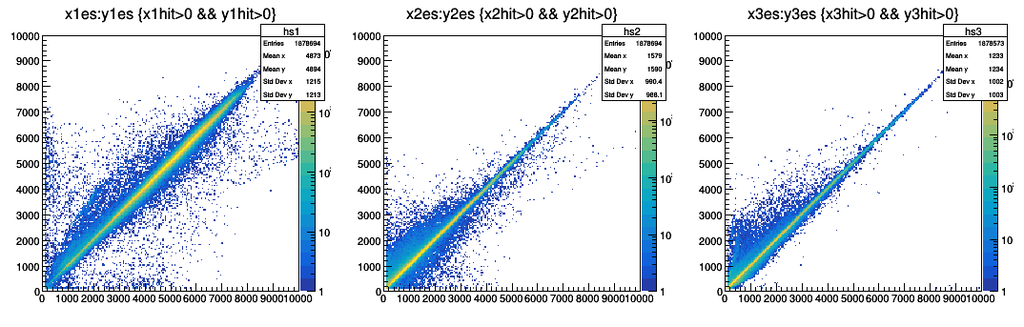

```python
c1->Clear();
c1->SetWindowSize(1200,300);
c1->Divide(3,1);
c1->cd(1);
tree->Draw("x1es:y1es>>hs1(200,0,10000,200,0,10000)","x1hit>0 && y1hit>0","colz");
gPad->SetLogz();
c1->cd(2);
tree->Draw("x2es:y2es>>hs2(200,0,10000,200,0,10000)","x2hit>0 && y2hit>0","colz");
gPad->SetLogz();
c1->cd(3);
tree->Draw("x3es:y3es>>hs3(200,0,10000,200,0,10000)","x3hit>0 && y3hit>0","colz");
gPad->SetLogz();
c1->Draw();
```

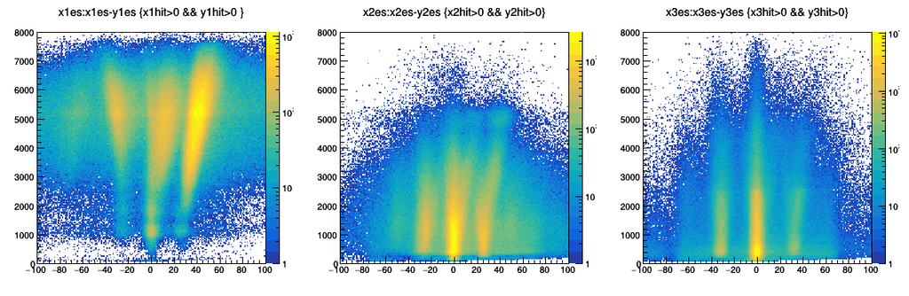

```python
TCut cdet1 ="x1hit>0 && y1hit>0 ";
TCut cdet2 ="x2hit>0 && y2hit>0";
TCut cdet3 ="x3hit>0 && y3hit>0";
c1->Clear();
c1->SetWindowSize(1200,400);
gStyle->SetOptStat(0);
c1->Divide(3,1);
c1->cd(1);
tree->Draw("x1es:x1es-y1es>>hds1(200,-100,100,200,0,8000)",cdet1,"colz");
gPad->SetLogz();
c1->cd(2);
tree->Draw("x2es:x2es-y2es>>hds2(200,-100,100,200,0,8000)",cdet2,"colz");
gPad->SetLogz();
c1->cd(3);
tree->Draw("x3es:x3es-y3es>>hds3(200,-100,100,200,0,8000)",cdet3,"colz");
gPad->SetLogz();
c1->Draw();
```

### 1.1 x-y能量差与x，y的多重性差值的关联

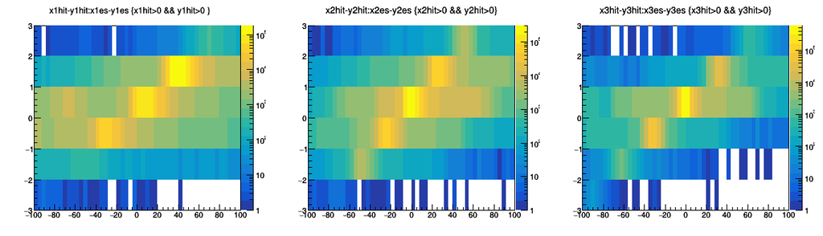

```python
c1->Clear();
c1->SetWindowSize(1200,300);
gStyle->SetOptStat(0);
c1->Divide(3,1);
c1->cd(1);
tree->Draw("x1hit-y1hit:x1es-y1es>>h2ds1(50,-100,100,6,-3,3)",cdet1 ,"colz");
gPad->SetLogz();
c1->cd(2);
tree->Draw("x2hit-y2hit:x2es-y2es>>h2ds2(50,-100,100,6,-3,3)",cdet2,"colz");
gPad->SetLogz();
c1->cd(3);
tree->Draw("x3hit-y3hit:x3es-y3es>>h2ds3(50,-100,100,6,-3,3)",cdet3,"colz");
gPad->SetLogz();
c1->Draw();
```

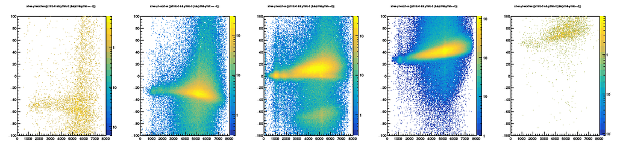

```python
c1->Clear();
c1->SetWindowSize(1200,250);
gStyle->SetOptStat(0);
c1->Divide(5,1);
c1->cd(1);
tree->Draw("x1es-y1es:x1es>>h1(200,0,8000,200,-100,100)",cdet1 && "x1hit-y1hit == -2","colz");
gPad->SetLogz();
c1->cd(2);
tree->Draw("x1es-y1es:x1es>>h2(200,0,8000,200,-100,100)",cdet1 && "x1hit-y1hit == -1","colz");
gPad->SetLogz();
c1->cd(3);
tree->Draw("x1es-y1es:x1es>>h3(200,0,8000,200,-100,100)",cdet1 && "x1hit-y1hit==0","colz");
gPad->SetLogz();
c1->cd(4);
tree->Draw("x1es-y1es:x1es>>h4(200,0,8000,200,-100,100)",cdet1 && "x1hit-y1hit==1","colz");
gPad->SetLogz();
c1->cd(5);
tree->Draw("x1es-y1es:x1es>>h5(200,0,8000,200,-100,100)",cdet1 && "x1hit-y1hit==2","colz");
gPad->SetLogz();
c1->Draw();
```

### 分析

DSSD的各个条经幅度归一化后，刻度后的幅度$A'_i$与能量的关系统一变为$E_i =kA’_i+b $。其中刻度系数$(k,b)$为参考条$x_{im}$ 的能量刻度系数$（k_{x_{im}},b_{x_{im}}）$。设x的多重性为$m_x$, y的多重性为$m_y$, 则 x和y侧的总能量分别为 $$ \begin{align} E_x=k\sum_\limits {i}A’_{xi}+m_xb \\ E_y=k\sum_\limits {j}A’_{yj}+m_yb \end{align} $$ 由$E_x=E_y$, 可得两侧幅度之差为 $$ \text{x1es-y1es} = \sum_\limits {i}A’_{xi}-\sum_\limits {j}A’_{yj}=(m_y-m_x)\frac{b}{k} \tag{1} $$

- **两侧多重性相同$m_x=m_y$，差值为0**。
- **两侧多重性不同，则差值不为零。多重性差别越大，差值的绝对值越大；差值的正负取决于b值的正负。**
  - 从数据观察，实验中DSSD1幅度A'对应的 $b/k\approx$ -25.

### 对幅度A'进行修正

- 引入修正后的幅度$A''$

$$ \begin{align} A''_i &= A'_i+b/k \tag{2}\\ E_i &=kA’_i+b = k(A''_i-b/k)+b\\ \to E_i &= kA''_i \tag{3} \end{align} $$

则有 $$ \text{x1es'-y1es'} = \sum_\limits {i}A’'_{xi}-\sum_\limits {j}A’'_{yj}=0 \tag{4} $$

**即修正后两侧幅度差值与多重性无关。**

- 按照上述关系修正后，两侧能量差值仍与一侧幅度有依赖关系。这是由相邻条之间的感应信号导致的。

**相邻条的细致的关联关系**

图(a) 所示为DSSD相邻的第 15 根条和第 16 根条的能量信号的关联。图中主要分为三个区域:A区域为条间能量共享信号，B 和 C 区域为相邻条感应信号，D 区域为 基线 (Pedestal) 信号。图 (b) 为图 (a) 横轴低能端的放大显示。可以看到，随着第 16 根条能量的提高，第 15 根条上必然以一定的比例产生一个小信号(低于 100 ch)， 我们称这种小信号为相邻条的感应信号。感应信号的幅度正比于源信号的幅度。

[figure not shown]

- 数据中呈现的最大偏移约为 $40/6000=0.006$, 对所研究物理目标基本没有影响。因此不尝试进行进一步修正。

### 1.2 修正后的关联关系

```python
tree->SetAlias("xesc","x1es+x1hit*(-25)");
tree->SetAlias("yesc","y1es+y1hit*(-25)");
tree->SetAlias("de","xesc-yesc");
tree->SetAlias("dhit","x1hit-y1hit");
```

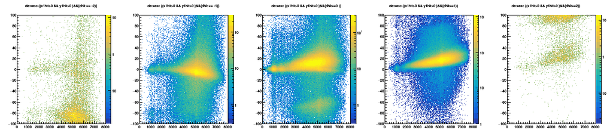

```python
c1->Clear();
c1->SetWindowSize(1200,250);
gStyle->SetOptStat(0);
c1->Divide(5,1);
c1->cd(1);
tree->Draw("de:xesc>>h1(200,0,8000,200,-100,100)",cdet1 && "dhit == -2","colz");
gPad->SetLogz();
c1->cd(2);
tree->Draw("de:xesc>>h2(200,0,8000,200,-100,100)",cdet1 && "dhit == -1","colz");
gPad->SetLogz();
c1->cd(3);
tree->Draw("de:xesc>>h3(200,0,8000,200,-100,100)",cdet1 && "dhit==0 ","colz");
gPad->SetLogz();
c1->cd(4);
tree->Draw("de:xesc>>h4(200,0,8000,200,-100,100)",cdet1 && "dhit==1","colz");
gPad->SetLogz();
c1->cd(5);
tree->Draw("de:xesc>>h5(200,0,8000,200,-100,100)",cdet1 && "dhit==2","colz");
gPad->SetLogz();
c1->Draw();
```

### 1.3 多粒子事件的条件

- 实验目的为探测入射核碎裂成多粒子事件，后续的处理主要考虑这部分事件。

#### 一个粒子入射

```python
TF1 *f1a = new TF1("f1a","0",0,8000);
TF1 *f1b = new TF1("f1b","20+0.004*x",0,8000);
TF1 *f1c = new TF1("f1c","-10-0.004*x",0,8000);
f1b->SetLineColor(kGreen);
f1c->SetLineColor(kGreen);
```

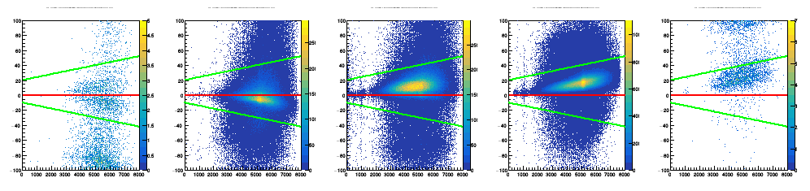

```python
TCut cs1 = "x1hit==1 && y1m==1|| y1hit==1 && x1m==1";
TCut cs2 = "x1hit==2 && y1hit==2 && x1m==1 && y1m==1";
TCut cs3 = "x1m==1 && y1m==1 && (x1hit!=y1hit)";
TCut cs = cs1 || cs2 || cs3 ;
TCut cdet2 = cdet1 && cs;//一个粒子入射
c1->Clear();
c1->SetWindowSize(800,200);
gStyle->SetOptStat(0);
c1->Divide(5,1);
c1->cd(1);
tree->Draw("de:xesc>>h1(200,0,8000,200,-100,100)",cdet2 && "dhit==-2","colz");
f1a->Draw("same"); f1b->Draw("same"); f1c->Draw("same");
c1->cd(2);
tree->Draw("de:xesc>>h2(200,0,8000,200,-100,100)",cdet2 && "dhit==-1","colz");
f1a->Draw("same"); f1b->Draw("same"); f1c->Draw("same");
c1->cd(3);
tree->Draw("de:xesc>>h3(200,0,8000,200,-100,100)",cdet2 && "dhit==0 ","colz");
f1a->Draw("same"); f1b->Draw("same"); f1c->Draw("same");
c1->cd(4);
tree->Draw("de:xesc>>h4(200,0,8000,200,-100,100)",cdet2 && "dhit==1","colz");
f1a->Draw("same"); f1b->Draw("same"); f1c->Draw("same");
c1->cd(5);
tree->Draw("de:xesc>>h5(200,0,8000,200,-100,100)",cdet2 && "dhit==2","colz");
f1a->Draw("same"); f1b->Draw("same"); f1c->Draw("same");
c1->Draw();
```

### 多粒子

- 包含多粒子以及部分一粒子
- cut条件应适当放宽，以免丢失有效统计。其中不满足关联的事件会在后续的cut(探测器之间，pid)被排除。

```python
f1a = new TF1("f1a","0",0,8000);
f1b = new TF1("f1b","22+0.004*x",0,8000);
f1c = new TF1("f1c","-20",0,8000);
f1b->SetLineColor(kGreen);
f1c->SetLineColor(kGreen);
```

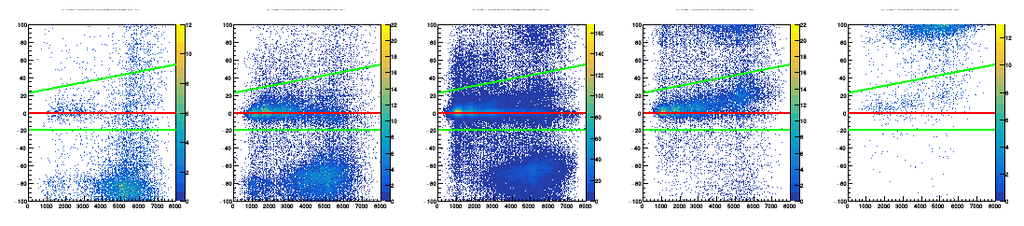

```python
TCut cm = cdet1 && !cs;//
c1->Clear();
c1->SetWindowSize(1200,250);
gStyle->SetOptStat(0);
c1->Divide(5,1);
c1->cd(1);
tree->Draw("de:xesc>>h1(200,0,8000,200,-100,100)",cm && "dhit == -2","colz");
f1a->Draw("same"); f1b->Draw("same"); f1c->Draw("same");
c1->cd(2);
tree->Draw("de:xesc>>h2(200,0,8000,200,-100,100)",cm && "dhit == -1","colz");
f1a->Draw("same"); f1b->Draw("same"); f1c->Draw("same");
//gPad->SetLogz();
c1->cd(3);
tree->Draw("de:xesc>>h3(200,0,8000,200,-100,100)",cm && "dhit==0 ","colz");
f1a->Draw("same"); f1b->Draw("same"); f1c->Draw("same");
c1->cd(4);
tree->Draw("de:xesc>>h4(200,0,8000,200,-100,100)",cm && "dhit==1","colz");
f1a->Draw("same"); f1b->Draw("same"); f1c->Draw("same");
c1->cd(5);
tree->Draw("de:xesc>>h5(200,0,8000,200,-100,100)",cm && "dhit==2","colz");
f1a->Draw("same"); f1b->Draw("same"); f1c->Draw("same");
c1->Draw();
```

## 2. 用Scan观察事件特征，找到分析思路

- 观察Scan的事件特征对事件进行分类：

### 分类：

```python
tree->SetAlias("xe","int(x1e-(25))");
tree->SetAlias("ye","int(y1e+(-25))");
TCut cde = "de < 15+0.004*xesc && de > -20";
```

```python
tree->Scan("x1:xe:y1:ye:int(de)",cde && cm  ,"",500,1);
```

```
*    Row   * Instance *        x1 *        xe *        y1 *        ye *   int(de) *
*       42 *        0 *        11 *      3166 *        17 *      3792 *        10 *
*       42 *        1 *        12 *       638 *        14 *       479 *        10 *
*       42 *        2 *         8 *       478 *           *         0 *        10 *
*       47 *        0 *        26 *      1307 *        23 *      1308 *        -3 *
*       47 *        1 *        29 *       419 *        21 *       422 *        -3 *
*       78 *        0 *        25 *       457 *        27 *       457 *         0 *
*       78 *        1 *        27 *       403 *        20 *       403 *         0 *
*      102 *        0 *        13 *      2230 *         9 *      2231 *         1 *
*      102 *        1 *        10 *      1882 *        16 *      1880 *         1 *
*      115 *        0 *        18 *       944 *         3 *       945 *         7 *
*      115 *        1 *        12 *       492 *        28 *       490 *         7 *
*      115 *        2 *        10 *       389 *        11 *       383 *         7 *
*      123 *        0 *        26 *       911 *        16 *       909 *         0 *
*      123 *        1 *        28 *       485 *         9 *       487 *         0 *
*      130 *        0 *         6 *       956 *        12 *       856 *        -3 *
*      130 *        1 *         1 *       552 *        29 *       552 *        -3 *
*      130 *        2 *           *         0 *        13 *       103 *        -3 *
*      161 *        0 *        18 *      1461 *        28 *      1461 *         0 *
*      161 *        1 *        25 *       650 *         5 *       650 *         0 *
*      171 *        0 *        24 *      2139 *         6 *      2374 *        21 *
*      171 *        1 *        25 *       243 *         5 *       106 *        21 *
*      171 *        2 *        11 *       119 *           *         0 *        21 *
*      175 *        0 *        18 *       626 *         4 *       626 *         4 *
*      175 *        1 *        19 *       529 *         3 *       528 *         4 *
*      175 *        2 *        20 *       507 *        20 *       504 *         4 *
*      187 *        0 *         2 *       652 *        14 *       652 *         3 *
*      187 *        1 *        12 *       562 *         6 *       561 *         3 *
*      187 *        2 *        11 *       538 *         5 *       450 *         3 *
*      187 *        3 *           *         0 *         4 *        85 *         3 *
*      188 *        0 *        16 *      2537 *        18 *      2541 *        -1 *
*      188 *        1 *        13 *       508 *        23 *       508 *        -1 *
*      188 *        2 *         1 *       417 *         2 *       416 *        -1 *
*      255 *        0 *        12 *      3643 *        11 *      3641 *         0 *
*      255 *        1 *        25 *       966 *         8 *       968 *         0 *
*      265 *        0 *         4 *      2042 *        17 *      2042 *        10 *
*      265 *        1 *        28 *       752 *        23 *      1277 *        10 *
*      265 *        2 *        27 *       535 *           *         0 *        10 *
*      278 *        0 *        12 *      1366 *        12 *      1367 *         0 *
*      278 *        1 *         8 *       951 *        17 *       949 *         0 *
```

[output cut: 13 more lines]

```
*      382 *        0 *        25 *      4469 *        12 *      4466 *         0 *
*      382 *        1 *        16 *       422 *         8 *       424 *         0 *
*      388 *        0 *        12 *      1813 *        18 *      1807 *         5 *
*      388 *        1 *         5 *       505 *        24 *       503 *         5 *
*      388 *        2 *        13 *       165 *        17 *       168 *         5 *
*      419 *        0 *        10 *      4040 *        14 *      4040 *         1 *
*      419 *        1 *        12 *       378 *         4 *       376 *         1 *
*      419 *        2 *         6 *       111 *         5 *       112 *         1 *
*      425 *        0 *        21 *      4182 *         0 *      4179 *         0 *
*      425 *        1 *        25 *       433 *        19 *       348 *         0 *
*      425 *        2 *           *         0 *        18 *        89 *         0 *
*      429 *        0 *        13 *      3906 *        17 *      6700 *        22 *
*      429 *        1 *        14 *      2820 *         7 *        85 *        22 *
*      429 *        2 *         6 *        81 *           *         0 *        22 *
==> 66 selected entries
```

```
Type <CR> to continue or q to quit ==> Type <CR> to continue or q to quit ==>
```

```python
tree->Scan("x1:xe:y1:ye:int(de)",cde && cm  ,"",500,500);
```

```
*    Row   * Instance *        x1 *        xe *        y1 *        ye *   int(de) *
*      517 *        0 *        19 *      1058 *         2 *      1058 *         0 *
*      517 *        1 *        10 *       673 *        12 *       528 *         0 *
*      517 *        2 *         9 *       502 *         9 *       500 *         0 *
*      517 *        3 *           *         0 *        17 *       147 *         0 *
*      519 *        0 *        29 *      2434 *        16 *      2436 *        -1 *
*      519 *        1 *        22 *       706 *         5 *       703 *        -1 *
*      519 *        2 *        23 *       595 *        15 *       598 *        -1 *
*      539 *        0 *        21 *      1014 *         9 *      1013 *         1 *
*      539 *        1 *         1 *       474 *        13 *       472 *         1 *
*      539 *        2 *        13 *       451 *         7 *       451 *         1 *
*      593 *        0 *        15 *       563 *        15 *       754 *         4 *
*      593 *        1 *         3 *       516 *        26 *       562 *         4 *
*      593 *        2 *         2 *       242 *           *         0 *         4 *
*      610 *        0 *        16 *      6635 *        13 *      4559 *        15 *
*      610 *        1 *        20 *       352 *        12 *      2059 *        15 *
*      610 *        2 *           *         0 *        15 *       353 *        15 *
*      613 *        0 *        26 *       619 *        18 *       618 *         1 *
*      613 *        1 *        22 *       548 *        25 *       547 *         1 *
*      639 *        0 *         5 *      3731 *        23 *      3734 *        -4 *
*      639 *        1 *        13 *       413 *        18 *       415 *        -4 *
*      670 *        0 *        14 *       511 *        24 *       676 *         5 *
*      670 *        1 *        12 *       272 *         8 *       506 *         5 *
*      670 *        2 *        11 *       238 *           *         0 *         5 *
*      670 *        3 *        15 *       166 *           *         0 *         5 *
*      684 *        0 *        14 *      4577 *        17 *      4576 *         6 *
*      684 *        1 *        23 *       121 *        10 *       120 *         6 *
*      684 *        2 *        27 *       105 *        29 *       100 *         6 *
*      687 *        0 *        30 *       700 *        18 *       694 *         9 *
*      687 *        1 *        29 *       606 *        12 *       603 *         9 *
*      695 *        0 *         3 *      1574 *         0 *      1158 *         0 *
*      695 *        1 *        17 *       595 *        14 *       595 *         0 *
*      695 *        2 *           *         0 *         1 *       415 *         0 *
*      718 *        0 *        13 *      5352 *        15 *      5204 *         0 *
*      718 *        1 *           *         0 *        19 *       149 *         0 *
*      720 *        0 *        20 *       633 *        11 *       633 *         0 *
*      720 *        1 *        17 *       603 *        10 *       601 *         0 *
*      728 *        0 *        10 *      1010 *         1 *      1008 *         1 *
*      728 *        1 *         8 *       803 *         3 *       802 *         1 *
*      728 *        2 *        13 *       423 *        20 *       423 *         1 *
```

[output cut: 13 more lines]

```
*      904 *        0 *        24 *      5044 *         7 *      5043 *         1 *
*      904 *        1 *        17 *       517 *        19 *       516 *         1 *
*      912 *        0 *        18 *      3222 *        13 *      4597 *        17 *
*      912 *        1 *        17 *      1392 *        10 *       194 *        17 *
*      912 *        2 *        24 *       194 *           *         0 *        17 *
*      964 *        0 *         7 *      4108 *         5 *      4106 *         3 *
*      964 *        1 *        14 *       455 *        15 *       454 *         3 *
*      982 *        0 *         4 *      3917 *        10 *      3913 *         4 *
*      982 *        1 *        24 *       375 *        13 *       376 *         4 *
*      982 *        2 *        16 *        91 *        20 *        90 *         4 *
*      994 *        0 *        26 *      1094 *        10 *      1244 *        11 *
*      994 *        1 *        18 *       712 *         2 *       710 *        11 *
*      994 *        2 *        17 *       520 *        21 *       515 *        11 *
*      994 *        3 *        27 *       153 *           *         0 *        11 *
==> 66 selected entries
```

```
Type <CR> to continue or q to quit ==> Type <CR> to continue or q to quit ==>
```